# Word Clouds of two Indian political arch rivals..

#### In this document, we extract the tweets used by these leaders on Twitter and anyalyse them to find out the key words used by them. In the process, we not only do some Natural Language Processing (NLP) and count the key words usage by each. but also visualise these words as word clouds.

We start with downloading the necessary packages.

```python
import pandas as pd
import numpy as np
import re
import tweepy
import time
import nltk
from nltk.stem import WordNetLemmatizer
from nltk.tokenize import word_tokenize
from nltk.corpus import stopwords
from nltk.probability import FreqDist
from PIL import Image
from wordcloud import WordCloud, STOPWORDS, ImageColorGenerator
import matplotlib.pyplot as plt
```

Next, after creatinga developer account with Twitter, we assign our private keys and and tokens as shown below. The keys and Token are masked below.

```python
TWITTER_CONSUMER_KEY = 'your_consumer_key'
TWITTER_CONSUMER_SECRET = 'your_consumer_secret'
TWITTER_ACCESS_TOKEN = 'your_access_token'
TWITTER_ACCESS_TOKEN_SECRET = 'your_access_token_secret'
```

Then, we initiate the necessary API conncetion with Twitter.

```python
auth = tweepy.OAuthHandler(TWITTER_CONSUMER_KEY, TWITTER_CONSUMER_SECRET)
auth.set_access_token(TWITTER_ACCESS_TOKEN,TWITTER_ACCESS_TOKEN_SECRET)
api = tweepy.API(auth)
```

```python
def tweets(username):
    count = 5000
    try:
        tweets = api.user_timeline(screen_name=username,
                           count=count,
                           include_rts = False,
                           # Necessary to keep full_text
                           # otherwise only the first 140 words are extracted
                           tweet_mode = 'extended'
                           )
        tweets_list = [[tweet.created_at, tweet.id, tweet.full_text] for tweet in tweets]
        tweets_df = pd.DataFrame(tweets_list, columns= ['tweet_time', 'tweet_id', 'tweet'])

    except BaseException as e:
          print('failed on_status,',str(e))
          time.sleep(3)
    return tweets_df
```

```python
tweets_rg = tweets('RahulGandhi')
tweets_rg
```

|  | tweet_time | tweet_id | tweet |
| --- | --- | --- | --- |
| 0 | 2022-02-08 14:50:02+00:00 | 1491061766776066049 | वे इतना जो मुस्कुरा रहे हैं, \nक्या डर है जिसक... |
| 1 | 2022-02-08 13:06:25+00:00 | 1491035691777925125 | Saddened to know of the death of Army Personne... |
| 2 | 2022-02-08 05:24:36+00:00 | 1490919471229575169 | PM Lies. https://t.co/wanjMiCGnN |
| 3 | 2022-02-07 04:31:47+00:00 | 1490543792797237251 | The unease of doing business.\nThe pain of job... |
| 4 | 2022-02-06 12:47:35+00:00 | 1490306174167703557 | पंजाब की जनता ने कांग्रेस पार्टी के CM चेहरे क... |
| ... | ... | ... | ... |
| 195 | 2021-11-14 03:29:57+00:00 | 1459725264037023747 | “What we need is a generation of peace.”\n- Pa... |
| 196 | 2021-11-13 12:40:34+00:00 | 1459501441748545541 | Bitcoin Scam is big. \n\nBut Bitcoin Scam Cove... |
| 197 | 2021-11-13 11:03:27+00:00 | 1459477002650480644 | मणिपुर में सेना के क़ाफ़िले पर हुए आतंकी हमले ... |
| 198 | 2021-11-12 07:29:31+00:00 | 1459060774241026048 | हमारी राष्ट्रीय सुरक्षा से आपराधिक खिलवाड़ की ... |
| 199 | 2021-11-12 06:54:41+00:00 | 1459052008779010076 | Our national security is unpardonably compromi... |

200 rows × 3 columns

```python
# def tweets (username):
#     count = 5000
#     try:
#      tweets = tweepy.Cursor(api.user_timeline,id=username).items(count)
#      tweets_list = [[tweet.created_at, tweet.id, tweet.text] for tweet in tweets]
#      tweets_df = pd.DataFrame(tweets_list, columns= ['tweet_time', 'tweet_id', 'tweet'])

#     except BaseException as e:
#           print('failed on_status,',str(e))
#           time.sleep(3)
#     return tweets_df
# tweets_rg = tweets('RahulGandhi')
# tweets_rg
```

```python
tweets_nm = tweets('narendramodi')
tweets_nm
```

|  | tweet_time | tweet_id | tweet |
| --- | --- | --- | --- |
| 0 | 2022-02-08 15:03:03+00:00 | 1491065041785073664 | Sadddened by the loss of lives of Indian Army ... |
| 1 | 2022-02-08 14:56:09+00:00 | 1491063304814571523 | ਪੰਜਾਬ ਦੀ ਮਜ਼ਬੂਤੀ ਦੇਸ਼ ਨੂੰ ਮਜ਼ਬੂਤ ਕਰਦੀ ਰਹੀ ਹੈ। ... |
| 2 | 2022-02-08 14:55:49+00:00 | 1491063223898058755 | ਸਾਡੇ ਕੋਲ ਪੰਜਾਬ ਦੀ ਤਰੱਕੀ ਲਈ ਇੱਕ ਨਿਸ਼ਚਿਤ ਦ੍ਰਿਸ਼ਟ... |
| 3 | 2022-02-08 14:55:24+00:00 | 1491063118050516995 | ਭਾਜਪਾ ਤੇ ਐਨਡੀਏ ਵਾਸਤੇ ਪੰਜਾਬ ਦੀ ਅਹਿਮੀਅਤ ਮਹਿਜ਼ ਸੀ... |
| 4 | 2022-02-08 14:09:05+00:00 | 1491051460020342785 | हमें गर्व के साथ कहना चाहिए कि भारत Mother of ... |
| ... | ... | ... | ... |
| 193 | 2022-01-24 14:03:49+00:00 | 1485614318809120771 | A unique e-commerce initiative called "Pashu M... |
| 194 | 2022-01-24 14:02:38+00:00 | 1485614018467627009 | Banita Dash has designed an automated sanitizi... |
| 195 | 2022-01-24 14:01:35+00:00 | 1485613754197118977 | The budding palaeontologist Aswatha Biju has a... |
| 196 | 2022-01-24 14:01:00+00:00 | 1485613608826454018 | Young Puhabi has been innovating to help COVID... |
| 197 | 2022-01-24 13:58:14+00:00 | 1485612912844877837 | Jui Abhijit Keskar has done remarkable work wh... |

198 rows × 3 columns

```python
# tweets_rg.to_csv("C:/Users/vsvas/Jupyter Notebooks/Kaggle-My notebooks/tweets_rg.csv")
# tweets_nm.to_csv("C:/Users/vsvas/Jupyter Notebooks/Kaggle-My notebooks/tweets_nm.csv")
```

```python
# tweets_rg = pd.read_csv("C:/Users/vsvas/Jupyter Notebooks/Kaggle-My notebooks/tweets_rg.csv")
# tweets_nm = pd.read_csv("C:/Users/vsvas/Jupyter Notebooks/Kaggle-My notebooks/tweets_nm.csv")
```

Next, we preprocess our data and remove unwanted characters in the tweets.

```python
tweets_rg.loc[:,'name'] = 'Rahul Gandhi'
tweets_nm.loc[:,'name'] = 'Narendra Modi'
```

```python
for df in [tweets_rg,tweets_nm]:
    df['tweet_text'] = df.tweet.map(lambda x: re.sub(r'\W+'," ",x))
display(tweets_rg.head(), tweets_nm.head())
```

|  | tweet_time | tweet_id | tweet | name | tweet_text |
| --- | --- | --- | --- | --- | --- |
| 0 | 2022-02-08 14:50:02+00:00 | 1491061766776066049 | वे इतना जो मुस्कुरा रहे हैं, \nक्या डर है जिसक... | Rahul Gandhi | व इतन ज म स क र रह ह क य डर ह ज सक छ प रह ह ht... |
| 1 | 2022-02-08 13:06:25+00:00 | 1491035691777925125 | Saddened to know of the death of Army Personne... | Rahul Gandhi | Saddened to know of the death of Army Personne... |
| 2 | 2022-02-08 05:24:36+00:00 | 1490919471229575169 | PM Lies. https://t.co/wanjMiCGnN | Rahul Gandhi | PM Lies https t co wanjMiCGnN |
| 3 | 2022-02-07 04:31:47+00:00 | 1490543792797237251 | The unease of doing business.\nThe pain of job... | Rahul Gandhi | The unease of doing business The pain of joble... |
| 4 | 2022-02-06 12:47:35+00:00 | 1490306174167703557 | पंजाब की जनता ने कांग्रेस पार्टी के CM चेहरे क... | Rahul Gandhi | प ज ब क जनत न क ग र स प र ट क CM च हर क र प म ... |

|  | tweet_time | tweet_id | tweet | name | tweet_text |
| --- | --- | --- | --- | --- | --- |
| 0 | 2022-02-08 15:03:03+00:00 | 1491065041785073664 | Sadddened by the loss of lives of Indian Army ... | Narendra Modi | Sadddened by the loss of lives of Indian Army ... |
| 1 | 2022-02-08 14:56:09+00:00 | 1491063304814571523 | ਪੰਜਾਬ ਦੀ ਮਜ਼ਬੂਤੀ ਦੇਸ਼ ਨੂੰ ਮਜ਼ਬੂਤ ਕਰਦੀ ਰਹੀ ਹੈ। ... | Narendra Modi | ਪ ਜ ਬ ਦ ਮਜ ਬ ਤ ਦ ਸ ਨ ਮਜ ਬ ਤ ਕਰਦ ਰਹ ਹ https t c... |
| 2 | 2022-02-08 14:55:49+00:00 | 1491063223898058755 | ਸਾਡੇ ਕੋਲ ਪੰਜਾਬ ਦੀ ਤਰੱਕੀ ਲਈ ਇੱਕ ਨਿਸ਼ਚਿਤ ਦ੍ਰਿਸ਼ਟ... | Narendra Modi | ਸ ਡ ਕ ਲ ਪ ਜ ਬ ਦ ਤਰ ਕ ਲਈ ਇ ਕ ਨ ਸ ਚ ਤ ਦ ਰ ਸ ਟ ਕ ... |
| 3 | 2022-02-08 14:55:24+00:00 | 1491063118050516995 | ਭਾਜਪਾ ਤੇ ਐਨਡੀਏ ਵਾਸਤੇ ਪੰਜਾਬ ਦੀ ਅਹਿਮੀਅਤ ਮਹਿਜ਼ ਸੀ... | Narendra Modi | ਭ ਜਪ ਤ ਐਨਡ ਏ ਵ ਸਤ ਪ ਜ ਬ ਦ ਅਹ ਮ ਅਤ ਮਹ ਜ ਸ ਟ ਦ ਨ... |
| 4 | 2022-02-08 14:09:05+00:00 | 1491051460020342785 | हमें गर्व के साथ कहना चाहिए कि भारत Mother of ... | Narendra Modi | हम गर व क स थ कहन च ह ए क भ रत Mother of Democ... |

```python
words = set(nltk.corpus.words.words())
len(words)
```

```
235892
```

```python
for df in [tweets_rg,tweets_nm]:
    df['tweet_text'] = df.tweet_text.map(lambda x: " ".join(w for w in nltk.wordpunct_tokenize(x) \
         if w.lower() in words or w.isalpha() and w.isascii()))
display(tweets_rg.head(), tweets_nm.head())
```

|  | tweet_time | tweet_id | tweet | name | tweet_text |
| --- | --- | --- | --- | --- | --- |
| 0 | 2022-02-08 14:50:02+00:00 | 1491061766776066049 | वे इतना जो मुस्कुरा रहे हैं, \nक्या डर है जिसक... | Rahul Gandhi | https t co VjCxWQXLYQ |
| 1 | 2022-02-08 13:06:25+00:00 | 1491035691777925125 | Saddened to know of the death of Army Personne... | Rahul Gandhi | Saddened to know of the death of Army Personne... |
| 2 | 2022-02-08 05:24:36+00:00 | 1490919471229575169 | PM Lies. https://t.co/wanjMiCGnN | Rahul Gandhi | PM Lies https t co wanjMiCGnN |
| 3 | 2022-02-07 04:31:47+00:00 | 1490543792797237251 | The unease of doing business.\nThe pain of job... | Rahul Gandhi | The unease of doing business The pain of joble... |
| 4 | 2022-02-06 12:47:35+00:00 | 1490306174167703557 | पंजाब की जनता ने कांग्रेस पार्टी के CM चेहरे क... | Rahul Gandhi | CM AawazPunjabDi https t co |

|  | tweet_time | tweet_id | tweet | name | tweet_text |
| --- | --- | --- | --- | --- | --- |
| 0 | 2022-02-08 15:03:03+00:00 | 1491065041785073664 | Sadddened by the loss of lives of Indian Army ... | Narendra Modi | Sadddened by the loss of lives of Indian Army ... |
| 1 | 2022-02-08 14:56:09+00:00 | 1491063304814571523 | ਪੰਜਾਬ ਦੀ ਮਜ਼ਬੂਤੀ ਦੇਸ਼ ਨੂੰ ਮਜ਼ਬੂਤ ਕਰਦੀ ਰਹੀ ਹੈ। ... | Narendra Modi | https t co |
| 2 | 2022-02-08 14:55:49+00:00 | 1491063223898058755 | ਸਾਡੇ ਕੋਲ ਪੰਜਾਬ ਦੀ ਤਰੱਕੀ ਲਈ ਇੱਕ ਨਿਸ਼ਚਿਤ ਦ੍ਰਿਸ਼ਟ... | Narendra Modi | https t co |
| 3 | 2022-02-08 14:55:24+00:00 | 1491063118050516995 | ਭਾਜਪਾ ਤੇ ਐਨਡੀਏ ਵਾਸਤੇ ਪੰਜਾਬ ਦੀ ਅਹਿਮੀਅਤ ਮਹਿਜ਼ ਸੀ... | Narendra Modi | https t co |
| 4 | 2022-02-08 14:09:05+00:00 | 1491051460020342785 | हमें गर्व के साथ कहना चाहिए कि भारत Mother of ... | Narendra Modi | Mother of Democracy https t co |

```python
tweets_rg = tweets_rg[~tweets_rg['tweet_text'].astype(str).str.startswith('https')]
tweets_nm = tweets_nm[~tweets_nm['tweet_text'].astype(str).str.startswith('https')]
display(tweets_rg.head(), tweets_nm.head())
```

|  | tweet_time | tweet_id | tweet | name | tweet_text |
| --- | --- | --- | --- | --- | --- |
| 1 | 2022-02-08 13:06:25+00:00 | 1491035691777925125 | Saddened to know of the death of Army Personne... | Rahul Gandhi | Saddened to know of the death of Army Personne... |
| 2 | 2022-02-08 05:24:36+00:00 | 1490919471229575169 | PM Lies. https://t.co/wanjMiCGnN | Rahul Gandhi | PM Lies https t co wanjMiCGnN |
| 3 | 2022-02-07 04:31:47+00:00 | 1490543792797237251 | The unease of doing business.\nThe pain of job... | Rahul Gandhi | The unease of doing business The pain of joble... |
| 4 | 2022-02-06 12:47:35+00:00 | 1490306174167703557 | पंजाब की जनता ने कांग्रेस पार्टी के CM चेहरे क... | Rahul Gandhi | CM AawazPunjabDi https t co |
| 5 | 2022-02-06 11:08:31+00:00 | 1490281244973998082 | Live: लुधियाना से Virtual Rally- कांग्रेस करेग... | Rahul Gandhi | Live Virtual Rally AawazPunjabDi https t co |

|  | tweet_time | tweet_id | tweet | name | tweet_text |
| --- | --- | --- | --- | --- | --- |
| 0 | 2022-02-08 15:03:03+00:00 | 1491065041785073664 | Sadddened by the loss of lives of Indian Army ... | Narendra Modi | Sadddened by the loss of lives of Indian Army ... |
| 4 | 2022-02-08 14:09:05+00:00 | 1491051460020342785 | हमें गर्व के साथ कहना चाहिए कि भारत Mother of ... | Narendra Modi | Mother of Democracy https t co |
| 6 | 2022-02-08 14:08:23+00:00 | 1491051283410735110 | Being selective about history, only hailing a ... | Narendra Modi | Being selective about history only hailing a s... |
| 7 | 2022-02-08 14:07:58+00:00 | 1491051182160334852 | Our actions can’t be determined by where we si... | Narendra Modi | Our actions can t be determined by where we si... |
| 8 | 2022-02-08 14:07:17+00:00 | 1491051006960050179 | It does not suit the members of the Congress t... | Narendra Modi | It does not suit the members of the Congress t... |

```python
tweets_rg['tweet_text'] = tweets_rg['tweet_text'].str.split('https').str[0]
tweets_nm['tweet_text'] = tweets_nm['tweet_text'].str.split('https').str[0]
display(tweets_rg.head(), tweets_nm.head())
```

|  | tweet_time | tweet_id | tweet | name | tweet_text |
| --- | --- | --- | --- | --- | --- |
| 1 | 2022-02-08 13:06:25+00:00 | 1491035691777925125 | Saddened to know of the death of Army Personne... | Rahul Gandhi | Saddened to know of the death of Army Personne... |
| 2 | 2022-02-08 05:24:36+00:00 | 1490919471229575169 | PM Lies. https://t.co/wanjMiCGnN | Rahul Gandhi | PM Lies |
| 3 | 2022-02-07 04:31:47+00:00 | 1490543792797237251 | The unease of doing business.\nThe pain of job... | Rahul Gandhi | The unease of doing business The pain of joble... |
| 4 | 2022-02-06 12:47:35+00:00 | 1490306174167703557 | पंजाब की जनता ने कांग्रेस पार्टी के CM चेहरे क... | Rahul Gandhi | CM AawazPunjabDi |
| 5 | 2022-02-06 11:08:31+00:00 | 1490281244973998082 | Live: लुधियाना से Virtual Rally- कांग्रेस करेग... | Rahul Gandhi | Live Virtual Rally AawazPunjabDi |

|  | tweet_time | tweet_id | tweet | name | tweet_text |
| --- | --- | --- | --- | --- | --- |
| 0 | 2022-02-08 15:03:03+00:00 | 1491065041785073664 | Sadddened by the loss of lives of Indian Army ... | Narendra Modi | Sadddened by the loss of lives of Indian Army ... |
| 4 | 2022-02-08 14:09:05+00:00 | 1491051460020342785 | हमें गर्व के साथ कहना चाहिए कि भारत Mother of ... | Narendra Modi | Mother of Democracy |
| 6 | 2022-02-08 14:08:23+00:00 | 1491051283410735110 | Being selective about history, only hailing a ... | Narendra Modi | Being selective about history only hailing a s... |
| 7 | 2022-02-08 14:07:58+00:00 | 1491051182160334852 | Our actions can’t be determined by where we si... | Narendra Modi | Our actions can t be determined by where we si... |
| 8 | 2022-02-08 14:07:17+00:00 | 1491051006960050179 | It does not suit the members of the Congress t... | Narendra Modi | It does not suit the members of the Congress t... |

Now, we will combine all the tweets into a single text sring for both the leaders.

```python
text_rg = " ".join(tweet for tweet in tweets_rg.tweet_text)
print ("There are {} words in the combination of all Rahul Gandhi's tweets.".format(len(text_rg)))
```

[output not shown]

```python
text_nm = " ".join(tweet for tweet in tweets_nm.tweet_text)
print ("There are {} words in the combination of all Narendra Modi's tweets.".format(len(text_rg)))
```

[output not shown]

Thenwe shall lemmatize allwords so that te different grammatical formsof same words can be consolidated into individualwords.

```python
wordnet_lemmatizer = WordNetLemmatizer()

def lemma(sen):
    sen_token = nltk.word_tokenize(sen)
    lemma_word = []
    for w in sen_token:
        word1 = wordnet_lemmatizer.lemmatize(w, pos = "n")
        word2 = wordnet_lemmatizer.lemmatize(word1, pos = "v")
        word3 = wordnet_lemmatizer.lemmatize(word2, pos = ("a"))
        lemma_word.append(word3)
    return ' '.join(lemma_word)
```

```python
tweets_rg['tweet_text'] = tweets_rg['tweet_text'].map(lambda k: lemma(k))
tweets_nm['tweet_text'] = tweets_nm['tweet_text'].map(lambda k: lemma(k))
display(tweets_rg.head(), tweets_nm.head())
```

|  | tweet_time | tweet_id | tweet | name | tweet_text |
| --- | --- | --- | --- | --- | --- |
| 1 | 2022-02-08 13:06:25+00:00 | 1491035691777925125 | Saddened to know of the death of Army Personne... | Rahul Gandhi | Saddened to know of the death of Army Personne... |
| 2 | 2022-02-08 05:24:36+00:00 | 1490919471229575169 | PM Lies. https://t.co/wanjMiCGnN | Rahul Gandhi | PM Lies |
| 3 | 2022-02-07 04:31:47+00:00 | 1490543792797237251 | The unease of doing business.\nThe pain of job... | Rahul Gandhi | The unease of do business The pain of jobless ... |
| 4 | 2022-02-06 12:47:35+00:00 | 1490306174167703557 | पंजाब की जनता ने कांग्रेस पार्टी के CM चेहरे क... | Rahul Gandhi | CM AawazPunjabDi |
| 5 | 2022-02-06 11:08:31+00:00 | 1490281244973998082 | Live: लुधियाना से Virtual Rally- कांग्रेस करेग... | Rahul Gandhi | Live Virtual Rally AawazPunjabDi |

|  | tweet_time | tweet_id | tweet | name | tweet_text |
| --- | --- | --- | --- | --- | --- |
| 0 | 2022-02-08 15:03:03+00:00 | 1491065041785073664 | Sadddened by the loss of lives of Indian Army ... | Narendra Modi | Sadddened by the loss of life of Indian Army p... |
| 4 | 2022-02-08 14:09:05+00:00 | 1491051460020342785 | हमें गर्व के साथ कहना चाहिए कि भारत Mother of ... | Narendra Modi | Mother of Democracy |
| 6 | 2022-02-08 14:08:23+00:00 | 1491051283410735110 | Being selective about history, only hailing a ... | Narendra Modi | Being selective about history only hail a sele... |
| 7 | 2022-02-08 14:07:58+00:00 | 1491051182160334852 | Our actions can’t be determined by where we si... | Narendra Modi | Our action can t be determine by where we sit ... |
| 8 | 2022-02-08 14:07:17+00:00 | 1491051006960050179 | It does not suit the members of the Congress t... | Narendra Modi | It doe not suit the member of the Congress to ... |

Now let us define the stopwords which are very common or very uncommon and carry little meaning, and we will further remove from our tweets data.

```python
stop_words_1 = set(stopwords.words('english'))
stop_words_2 = set(STOPWORDS)
stop_words_2.update(["amp","will","shri","S","ji","today","year","India","people","Day","ha", 'wa','thank','RT', 'The', 'This', 'A',
                    'I','Ji','In',"At",'It','He','His','On','ji'])
stop_words = stop_words_1.union(stop_words_2)
```

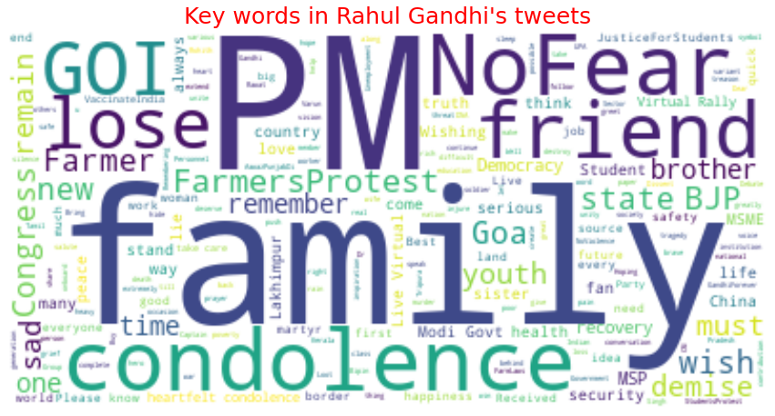

```python
text_rg = " ".join(tweet for tweet in tweets_rg.tweet_text)
wordcloud = WordCloud(stopwords=stop_words, background_color="white", max_words=200).generate(text_rg)
plt.figure(figsize=[15,10])
plt.imshow(wordcloud, interpolation='bilinear')
plt.title("Key words in Rahul Gandhi's tweets", size =25, color='red')
plt.axis("off")
plt.show()
```

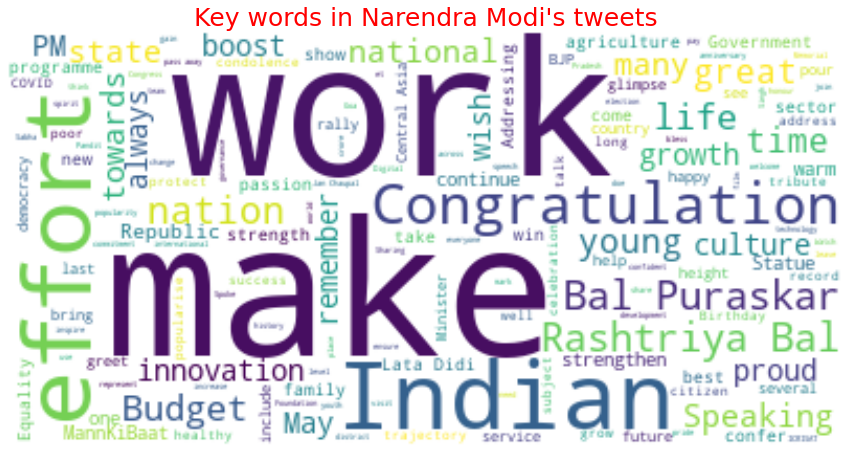

```python
text_nm = " ".join(tweet for tweet in tweets_nm.tweet_text)
wordcloud = WordCloud(stopwords=stop_words, background_color="white", max_words=200).generate(text_nm)
plt.figure(figsize=[15,10])
plt.imshow(wordcloud, interpolation='bilinear')
plt.title("Key words in Narendra Modi's tweets", size =25, color='red')
plt.axis("off")
plt.show()
```

Next we create these word clouds around India Flag theme.

```python
inc_mask = np.array(Image.open("C:/Users/vsvas/Jupyter Notebooks/Kaggle-My notebooks/inc.jpg"))
bjp_mask = np.array(Image.open("C:/Users/vsvas/Jupyter Notebooks/Kaggle-My notebooks/bjp.jpg"))
print(inc_mask.shape, bjp_mask.shape)
```

```
(169, 224, 3) (259, 335, 3)
```

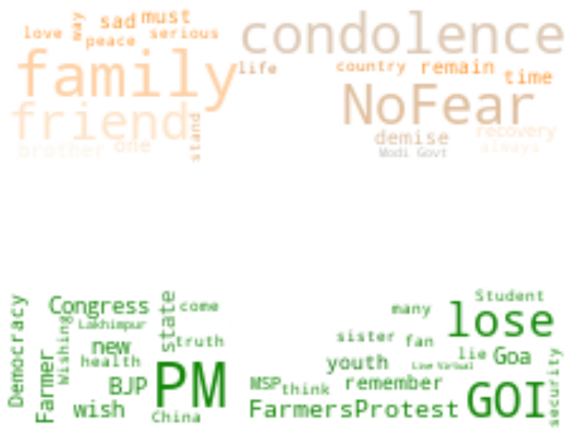

```python
wordcloud_rg = WordCloud(stopwords=stop_words_1.union(stop_words_2), background_color="white", mode="RGB", max_words=200, mask=inc_mask).generate(text_rg)
image_colors = ImageColorGenerator(inc_mask)
plt.figure(figsize=[15,10])
plt.imshow(wordcloud_rg.recolor(color_func=image_colors), interpolation="bilinear")
plt.axis("off")
plt.savefig("C:/Users/vsvas/Jupyter Notebooks/Kaggle-My notebooks/inc_wc.png", format="png")
plt.show()
```

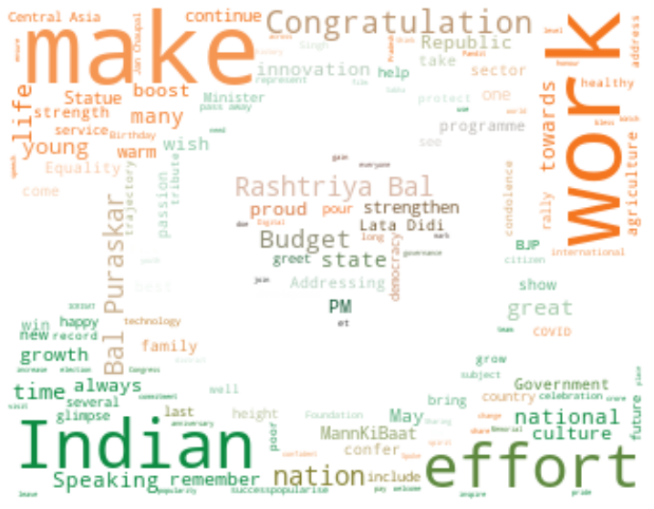

```python
wordcloud_nm = WordCloud(stopwords=stop_words_1.union(stop_words_2), background_color="white", mode="RGB", max_words=200, mask=bjp_mask).generate(text_nm)
image_colors = ImageColorGenerator(bjp_mask)
plt.figure(figsize=[15,10])
plt.imshow(wordcloud_nm.recolor(color_func=image_colors), interpolation="bilinear")
plt.axis("off")
plt.savefig("C:/Users/vsvas/Jupyter Notebooks/Kaggle-My notebooks/bjp_wc.png", format="png")
plt.show()
```

Now that we have seen teh word clouds,let us construct the frequency distribution of word counts and visualie them.

```python
word_tokens_rg = word_tokenize(text_rg)
filtered_word_tokens_rg = []
for w in word_tokens_rg:
    if w not in stop_words:
        filtered_word_tokens_rg.append(w)
```

```python
word_tokens_nm = word_tokenize(text_nm)
filtered_word_tokens_nm = []
for w in word_tokens_nm:
    if w not in stop_words:
        filtered_word_tokens_nm.append(w)
```

```python
fdist_rg = FreqDist(filtered_word_tokens_rg)
fdist_rg
```

```
FreqDist({'My': 17, 'condolence': 15, 'family': 13, 'PM': 13, 'NoFear': 11, 'friend': 9, 'GOI': 8, 'We': 7, 'lose': 7, 'FarmersProtest': 7, ...})
```

```python
fdist_nm = FreqDist(filtered_word_tokens_nm)
fdist_nm
```

```
FreqDist({'make': 16, 'work': 16, 'effort': 15, 'Bal': 15, 'Rashtriya': 14, 'Puraskar': 14, 'nation': 13, 'Indian': 12, 'Congratulations': 11, 'Budget': 11, ...})
```

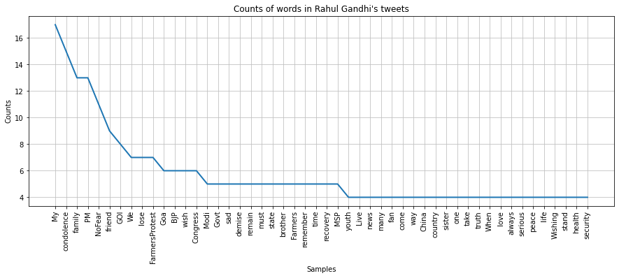

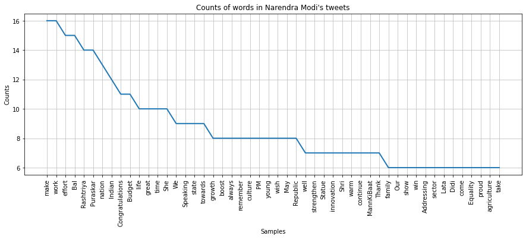

```python
plt.figure(figsize=[15,5])
plt.title("Counts of words in Rahul Gandhi's tweets")
fdist_rg.plot(50,cumulative=False)
plt.figure(figsize=[15,5])
plt.title("Counts of words in Narendra Modi's tweets")
fdist_nm.plot(50,cumulative=False)
plt.show()
```